# Practical Machine Learning: Peer Assignment

### GBM

Fit generalized boosted regression model.

```r
fit_gbm <- train(classe ~ ., data = training, method = "gbm", trControl = myControl)
fit_gbm
```

```
## Stochastic Gradient Boosting
##
## 14718 samples
##    52 predictor
##     5 classes: 'A', 'B', 'C', 'D', 'E'
##
## No pre-processing
## Resampling: Cross-Validated (3 fold)
## Summary of sample sizes: 9811, 9812, 9813
## Resampling results across tuning parameters:
##
##   interaction.depth  n.trees  Accuracy   Kappa
##   1                   50      0.7544493  0.6888332
##   1                  100      0.8175696  0.7691852
##   1                  150      0.8516096  0.8122572
##   2                   50      0.8552784  0.8166716
##   2                  100      0.9050815  0.8799015
##   2                  150      0.9289979  0.9101683
##   3                   50      0.8939381  0.8657228
##   3                  100      0.9381709  0.9217718
##   3                  150      0.9578745  0.9467109
##
## Tuning parameter 'shrinkage' was held constant at a value of 0.1
##
## Tuning parameter 'n.minobsinnode' was held constant at a value of 10
## Accuracy was used to select the optimal model using  the largest value.
## The final values used for the model were n.trees = 150,
##  interaction.depth = 3, shrinkage = 0.1 and n.minobsinnode = 10.
```

### Random Forest

Fit random forest model.

```r
fit_rf <- train(classe ~ ., data = training, method = "rf", trControl = myControl)
fit_rf
```

```
## Random Forest
##
## 14718 samples
##    52 predictor
##     5 classes: 'A', 'B', 'C', 'D', 'E'
##
## No pre-processing
## Resampling: Cross-Validated (3 fold)
## Summary of sample sizes: 9813, 9811, 9812
## Resampling results across tuning parameters:
##
##   mtry  Accuracy   Kappa
##    2    0.9884496  0.9853865
##   27    0.9885176  0.9854731
##   52    0.9805683  0.9754160
##
## Accuracy was used to select the optimal model using  the largest value.
## The final value used for the model was mtry = 27.
```

## Model Performance

Collect resampling results from each model to compare model performance.

```r
model_list <- list(rpart = fit_rpart, gbm = fit_gbm, rf = fit_rf)

resamps <- resamples(model_list)
resamps
```

```
##
## Call:
## resamples.default(x = model_list)
##
## Models: rpart, gbm, rf
## Number of resamples: 3
## Performance metrics: Accuracy, Kappa
## Time estimates for: everything, final model fit
```

### Resample Summary

View summary of resample results. The random forest model appears to have the highest accuracy.

```r
summary(resamps)
```

```
##
## Call:
## summary.resamples(object = resamps)
##
## Models: rpart, gbm, rf
## Number of resamples: 3
##
## Accuracy
##            Min.   1st Qu.    Median      Mean   3rd Qu.      Max. NA's
## rpart 0.4951080 0.5040244 0.5129407 0.5091729 0.5162053 0.5194699    0
## gbm   0.9555646 0.9565795 0.9575943 0.9578745 0.9590295 0.9604646    0
## rf    0.9871612 0.9880771 0.9889931 0.9885176 0.9891958 0.9893986    0
##
## Kappa
##            Min.   1st Qu.    Median      Mean   3rd Qu.      Max. NA's
## rpart 0.3408044 0.3528179 0.3648315 0.3596799 0.3691177 0.3734039    0
## gbm   0.9437978 0.9450837 0.9463697 0.9467109 0.9481675 0.9499653    0
## rf    0.9837565 0.9849159 0.9860753 0.9854731 0.9863315 0.9865876    0
```

### Resample Dotplot

The dotplot visually confirms that the random forest model produces the highest accuracy.

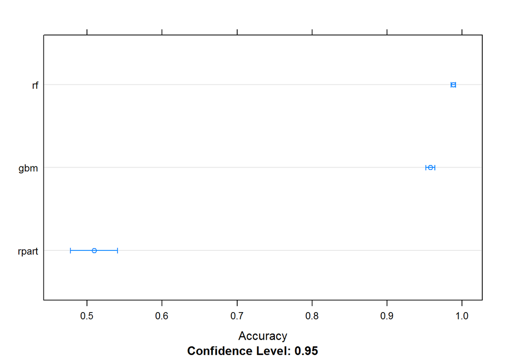

```r
dotplot(resamps, metric = "Accuracy")
```

## Predictions

Predict the target variable in the validation set using the random forest model. The accuracy is 100% so hopefully we haven’t overfit. We’ll apply the model to the hold out set and submit to check our performance.

```r
predictions <- predict(fit_rf,  validation)
confusionMatrix(predictions, validation$classe)
```

```
## Confusion Matrix and Statistics
##
##           Reference
## Prediction    A    B    C    D    E
##          A 1034    0    0    0    0
##          B    0  737    0    0    0
##          C    0    0  632    0    0
##          D    0    0    0  595    0
##          E    0    0    0    0  655
##
## Overall Statistics
##
##                Accuracy : 1
##                  95% CI : (0.999, 1)
##     No Information Rate : 0.2831
##     P-Value [Acc > NIR] : < 2.2e-16
##
##                   Kappa : 1
##  Mcnemar's Test P-Value : NA
##
## Statistics by Class:
##
##                      Class: A Class: B Class: C Class: D Class: E
## Sensitivity            1.0000   1.0000    1.000   1.0000   1.0000
## Specificity            1.0000   1.0000    1.000   1.0000   1.0000
## Pos Pred Value         1.0000   1.0000    1.000   1.0000   1.0000
## Neg Pred Value         1.0000   1.0000    1.000   1.0000   1.0000
## Prevalence             0.2831   0.2018    0.173   0.1629   0.1793
## Detection Rate         0.2831   0.2018    0.173   0.1629   0.1793
## Detection Prevalence   0.2831   0.2018    0.173   0.1629   0.1793
## Balanced Accuracy      1.0000   1.0000    1.000   1.0000   1.0000
```

## Variable Importance

Visualize the variable importance to determine which fields are most predictive. Roll_belt is the most predictive followed by pitch_forearm and yaw_belt.

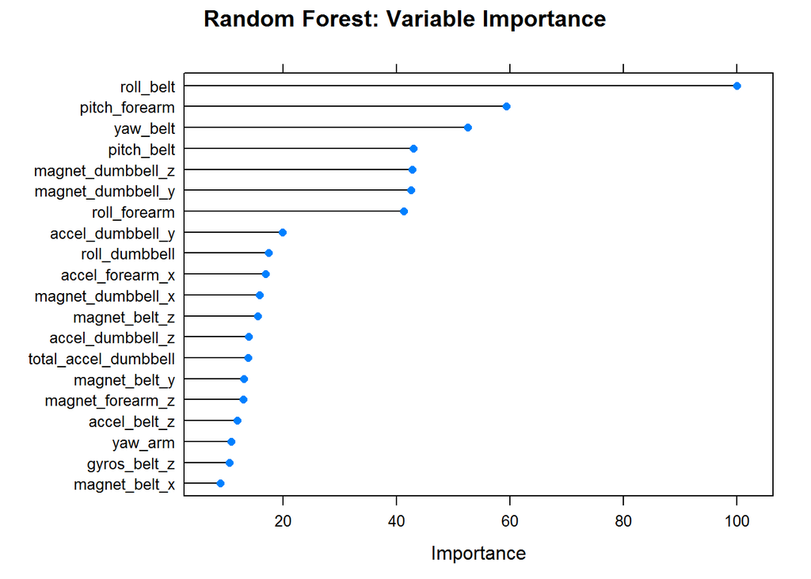

```r
imp <- varImp(fit_rf)
plot(imp, top = 20, main = "Random Forest: Variable Importance")
```

## Expected Out of Sample Error

The expected out of sample error is calculated as 1 - accuracy of validation set. Therefore we expect the error rate to be 0% when predicting the test set target variables.

## Predictions

Predict the target variable in the test set.

```r
pred <- predict(fit_rf, test)

pred
```

```
##  [1] B A B A A E D B A A B C B A E E A B B B
## Levels: A B C D E
```